# Risk Factor Analysis

## Outcome Variable

**Outcome Variable:** stunted

## Predictor Variables

**Intervention Variable:** gagebrth

**Adjustment Set:**

unadjusted

## Stratifying Variables

The analysis was stratified on these variable(s):

- agecat
- studyid

The following strata were considered:

- agecat: 12 months, studyid: ki1000108-CMC-V-BCS-2002
- agecat: 12 months, studyid: ki1000108-IRC
- agecat: 12 months, studyid: ki1000109-EE
- agecat: 12 months, studyid: ki1066203-TanzaniaChild2
- agecat: 12 months, studyid: ki1101329-Keneba
- agecat: 12 months, studyid: ki1113344-GMS-Nepal
- agecat: 12 months, studyid: ki1135781-COHORTS
- agecat: 18 months, studyid: ki1000108-CMC-V-BCS-2002
- agecat: 18 months, studyid: ki1000108-IRC
- agecat: 18 months, studyid: ki1000109-EE
- agecat: 18 months, studyid: ki1066203-TanzaniaChild2
- agecat: 18 months, studyid: ki1101329-Keneba
- agecat: 18 months, studyid: ki1113344-GMS-Nepal
- agecat: 18 months, studyid: ki1135781-COHORTS
- agecat: 24 months, studyid: ki1000108-CMC-V-BCS-2002
- agecat: 24 months, studyid: ki1000108-IRC
- agecat: 24 months, studyid: ki1066203-TanzaniaChild2
- agecat: 24 months, studyid: ki1101329-Keneba
- agecat: 24 months, studyid: ki1113344-GMS-Nepal
- agecat: 24 months, studyid: ki1135781-COHORTS
- agecat: 3 months, studyid: ki1000108-CMC-V-BCS-2002
- agecat: 3 months, studyid: ki1000108-IRC
- agecat: 3 months, studyid: ki1000109-EE
- agecat: 3 months, studyid: ki1066203-TanzaniaChild2
- agecat: 3 months, studyid: ki1101329-Keneba
- agecat: 3 months, studyid: ki1113344-GMS-Nepal
- agecat: 3 months, studyid: ki1135781-COHORTS
- agecat: 6 months, studyid: ki1000108-CMC-V-BCS-2002
- agecat: 6 months, studyid: ki1000108-IRC
- agecat: 6 months, studyid: ki1000109-EE
- agecat: 6 months, studyid: ki1066203-TanzaniaChild2
- agecat: 6 months, studyid: ki1101329-Keneba
- agecat: 6 months, studyid: ki1113344-GMS-Nepal
- agecat: 6 months, studyid: ki1135781-COHORTS
- agecat: 9 months, studyid: ki1000108-CMC-V-BCS-2002
- agecat: 9 months, studyid: ki1000108-IRC
- agecat: 9 months, studyid: ki1000109-EE
- agecat: 9 months, studyid: ki1066203-TanzaniaChild2
- agecat: 9 months, studyid: ki1101329-Keneba
- agecat: 9 months, studyid: ki1113344-GMS-Nepal
- agecat: 9 months, studyid: ki1135781-COHORTS
- agecat: Birth, studyid: ki1000108-CMC-V-BCS-2002
- agecat: Birth, studyid: ki1000108-IRC
- agecat: Birth, studyid: ki1000109-EE
- agecat: Birth, studyid: ki1101329-Keneba
- agecat: Birth, studyid: ki1135781-COHORTS

### Dropped Strata

Some strata were dropped due to rare outcomes:

- agecat: Birth, studyid: ki1000108-CMC-V-BCS-2002
- agecat: Birth, studyid: ki1000109-EE
- agecat: 3 months, studyid: ki1000109-EE
- agecat: 3 months, studyid: ki1113344-GMS-Nepal
- agecat: 6 months, studyid: ki1000109-EE
- agecat: 6 months, studyid: ki1113344-GMS-Nepal
- agecat: 9 months, studyid: ki1000109-EE
- agecat: 9 months, studyid: ki1113344-GMS-Nepal
- agecat: 12 months, studyid: ki1000109-EE
- agecat: 12 months, studyid: ki1113344-GMS-Nepal
- agecat: 18 months, studyid: ki1000109-EE
- agecat: 18 months, studyid: ki1113344-GMS-Nepal
- agecat: 24 months, studyid: ki1066203-TanzaniaChild2
- agecat: 24 months, studyid: ki1113344-GMS-Nepal

## Methods Detail

We’re interested in the causal parameters $E[Y_a]$ for all values of $a \in \mathcal{A}$. These parameters represent the mean outcome if, possibly contrary to fact, we intervened to set all units to have $A=a$. Under the randomization and positivity assumptions, these are identified by the statistical parameters $\psi_a=E_W[E_{Y|A,W}(Y|A=a,W)]$. In addition, we’re interested in the mean of $Y$, $E[Y]$ under no intervention (the observed mean). We will estimate these parameters by using SuperLearner to fit the relevant likelihood factors – $E_{Y|A,W}(Y|A=a,W)$ and $p(A=a|W)$, and then updating our likelihood fit using a joint TMLE.

For unadjusted analyses ($W=\{\}$), initial likelihoods were estimated using Lrnr_glm to estimate the simple $E(Y|A)$ and Lrnr_mean to estimate $p(A)$. For adjusted analyses, a small library containing Lrnr_glmnet, Lrnr_xgboost, and Lrnr_mean was used.

Having estimated these parameters, we will then use the delta method to estimate relative risks and attributable risks relative to a prespecified baseline level of $A$.

# Results Detail

## Results Plots

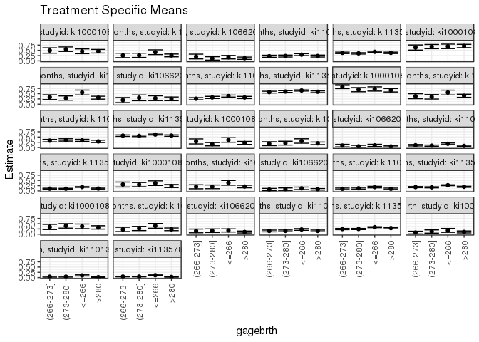

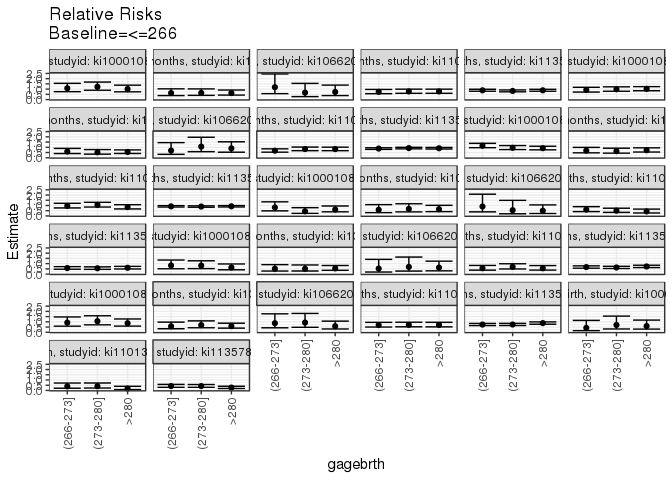

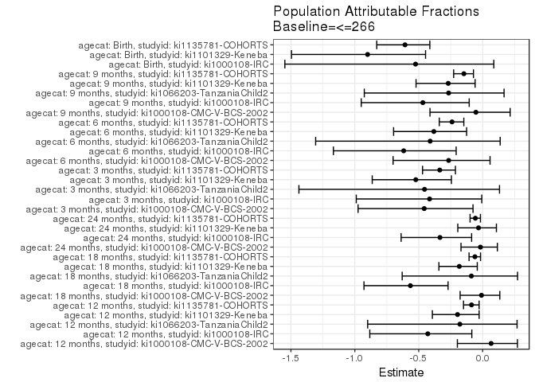

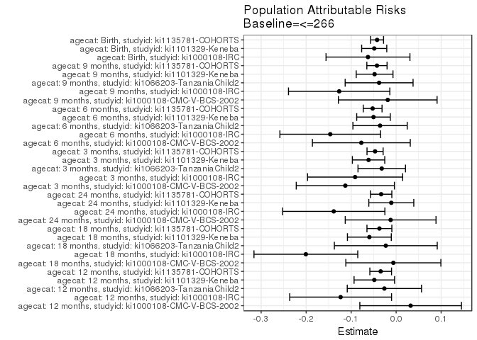

## Data Summary

| agecat | studyid | A | n | nA | nAY0 | nAY1 |
| --- | --- | --- | --- | --- | --- | --- |
| Birth | ki1000108-CMC-V-BCS-2002 | <=266 | 90 | 18 | 16 | 2 |
| Birth | ki1000108-CMC-V-BCS-2002 | (266-273] | 90 | 15 | 11 | 4 |
| Birth | ki1000108-CMC-V-BCS-2002 | (273-280] | 90 | 18 | 14 | 4 |
| Birth | ki1000108-CMC-V-BCS-2002 | >280 | 90 | 39 | 33 | 6 |
| Birth | ki1000108-IRC | <=266 | 369 | 66 | 54 | 12 |
| Birth | ki1000108-IRC | (266-273] | 369 | 65 | 60 | 5 |
| Birth | ki1000108-IRC | (273-280] | 369 | 71 | 62 | 9 |
| Birth | ki1000108-IRC | >280 | 369 | 167 | 149 | 18 |
| Birth | ki1000109-EE | <=266 | 2 | 2 | 1 | 1 |
| Birth | ki1000109-EE | (266-273] | 2 | 0 | 0 | 0 |
| Birth | ki1000109-EE | (273-280] | 2 | 0 | 0 | 0 |
| Birth | ki1000109-EE | >280 | 2 | 0 | 0 | 0 |
| Birth | ki1066203-TanzaniaChild2 | <=266 | 0 | 0 | 0 | 0 |
| Birth | ki1066203-TanzaniaChild2 | (266-273] | 0 | 0 | 0 | 0 |
| Birth | ki1066203-TanzaniaChild2 | (273-280] | 0 | 0 | 0 | 0 |
| Birth | ki1066203-TanzaniaChild2 | >280 | 0 | 0 | 0 | 0 |
| Birth | ki1101329-Keneba | <=266 | 1515 | 457 | 410 | 47 |
| Birth | ki1101329-Keneba | (266-273] | 1515 | 324 | 311 | 13 |
| Birth | ki1101329-Keneba | (273-280] | 1515 | 360 | 345 | 15 |
| Birth | ki1101329-Keneba | >280 | 1515 | 374 | 367 | 7 |
| Birth | ki1113344-GMS-Nepal | <=266 | 0 | 0 | 0 | 0 |
| Birth | ki1113344-GMS-Nepal | (266-273] | 0 | 0 | 0 | 0 |
| Birth | ki1113344-GMS-Nepal | (273-280] | 0 | 0 | 0 | 0 |
| Birth | ki1113344-GMS-Nepal | >280 | 0 | 0 | 0 | 0 |
| Birth | ki1135781-COHORTS | <=266 | 4607 | 1857 | 1649 | 208 |
| Birth | ki1135781-COHORTS | (266-273] | 4607 | 876 | 835 | 41 |
| Birth | ki1135781-COHORTS | (273-280] | 4607 | 926 | 883 | 43 |
| Birth | ki1135781-COHORTS | >280 | 4607 | 948 | 919 | 29 |
| 3 months | ki1000108-CMC-V-BCS-2002 | <=266 | 340 | 75 | 48 | 27 |
| 3 months | ki1000108-CMC-V-BCS-2002 | (266-273] | 340 | 55 | 39 | 16 |

[output cut: 166 more lines]

## Results Table

### Parameter: TSM

| agecat | studyid | intervention_level | baseline_level | estimate | ci_lower | ci_upper |
| --- | --- | --- | --- | --- | --- | --- |
| Birth | ki1000108-IRC | <=266 | NA | 0.1818182 | 0.0886411 | 0.2749952 |
| Birth | ki1000108-IRC | (266-273] | NA | 0.0769231 | 0.0120555 | 0.1417907 |
| Birth | ki1000108-IRC | (273-280] | NA | 0.1267606 | 0.0492668 | 0.2042544 |
| Birth | ki1000108-IRC | >280 | NA | 0.1077844 | 0.0606876 | 0.1548813 |
| Birth | ki1101329-Keneba | <=266 | NA | 0.1028446 | 0.0749861 | 0.1307032 |
| Birth | ki1101329-Keneba | (266-273] | NA | 0.0401235 | 0.0187475 | 0.0614994 |
| Birth | ki1101329-Keneba | (273-280] | NA | 0.0416667 | 0.0210180 | 0.0623154 |
| Birth | ki1101329-Keneba | >280 | NA | 0.0187166 | 0.0049772 | 0.0324559 |
| Birth | ki1135781-COHORTS | <=266 | NA | 0.1120086 | 0.0976630 | 0.1263542 |
| Birth | ki1135781-COHORTS | (266-273] | NA | 0.0468037 | 0.0328151 | 0.0607923 |
| Birth | ki1135781-COHORTS | (273-280] | NA | 0.0464363 | 0.0328815 | 0.0599911 |
| Birth | ki1135781-COHORTS | >280 | NA | 0.0305907 | 0.0196275 | 0.0415540 |
| 3 months | ki1000108-CMC-V-BCS-2002 | <=266 | NA | 0.3600000 | 0.2512077 | 0.4687923 |
| 3 months | ki1000108-CMC-V-BCS-2002 | (266-273] | NA | 0.2909091 | 0.1707004 | 0.4111178 |
| 3 months | ki1000108-CMC-V-BCS-2002 | (273-280] | NA | 0.1585366 | 0.0793661 | 0.2377070 |
| 3 months | ki1000108-CMC-V-BCS-2002 | >280 | NA | 0.2187500 | 0.1470281 | 0.2904719 |
| 3 months | ki1000108-IRC | <=266 | NA | 0.3108108 | 0.2052236 | 0.4163980 |
| 3 months | ki1000108-IRC | (266-273] | NA | 0.1818182 | 0.0886470 | 0.2749893 |
| 3 months | ki1000108-IRC | (273-280] | NA | 0.2077922 | 0.1170522 | 0.2985322 |
| 3 months | ki1000108-IRC | >280 | NA | 0.2000000 | 0.1397932 | 0.2602068 |
| 3 months | ki1066203-TanzaniaChild2 | <=266 | NA | 0.1023622 | 0.0495944 | 0.1551300 |
| 3 months | ki1066203-TanzaniaChild2 | (266-273] | NA | 0.0919540 | 0.0311783 | 0.1527298 |
| 3 months | ki1066203-TanzaniaChild2 | (273-280] | NA | 0.0561798 | 0.0082958 | 0.1040638 |
| 3 months | ki1066203-TanzaniaChild2 | >280 | NA | 0.0506329 | 0.0226940 | 0.0785719 |
| 3 months | ki1101329-Keneba | <=266 | NA | 0.1784897 | 0.1425751 | 0.2144043 |
| 3 months | ki1101329-Keneba | (266-273] | NA | 0.1081967 | 0.0733236 | 0.1430698 |
| 3 months | ki1101329-Keneba | (273-280] | NA | 0.0890805 | 0.0591412 | 0.1190197 |
| 3 months | ki1101329-Keneba | >280 | NA | 0.0767045 | 0.0488941 | 0.1045150 |
| 3 months | ki1135781-COHORTS | <=266 | NA | 0.1864035 | 0.1685298 | 0.2042772 |
| 3 months | ki1135781-COHORTS | (266-273] | NA | 0.1075145 | 0.0868691 | 0.1281598 |

[output cut: 98 more lines]

### Parameter: E(Y)

| agecat | studyid | intervention_level | baseline_level | estimate | ci_lower | ci_upper |
| --- | --- | --- | --- | --- | --- | --- |
| Birth | ki1000108-IRC | NA | NA | 0.1192412 | 0.1158740 | 0.1226084 |
| Birth | ki1101329-Keneba | NA | NA | 0.0541254 | 0.0524515 | 0.0557993 |
| Birth | ki1135781-COHORTS | NA | NA | 0.0696766 | 0.0686577 | 0.0706955 |
| 3 months | ki1000108-CMC-V-BCS-2002 | NA | NA | 0.2470588 | 0.2392971 | 0.2548205 |
| 3 months | ki1000108-IRC | NA | NA | 0.2196382 | 0.2151427 | 0.2241338 |
| 3 months | ki1066203-TanzaniaChild2 | NA | NA | 0.0703704 | 0.0684454 | 0.0722953 |
| 3 months | ki1101329-Keneba | NA | NA | 0.1171983 | 0.1150405 | 0.1193562 |
| 3 months | ki1135781-COHORTS | NA | NA | 0.1395810 | 0.1384605 | 0.1407016 |
| 6 months | ki1000108-CMC-V-BCS-2002 | NA | NA | 0.2910663 | 0.2856512 | 0.2964814 |
| 6 months | ki1000108-IRC | NA | NA | 0.2371134 | 0.2300633 | 0.2441635 |
| 6 months | ki1066203-TanzaniaChild2 | NA | NA | 0.0870488 | 0.0851514 | 0.0889462 |
| 6 months | ki1101329-Keneba | NA | NA | 0.1317322 | 0.1299160 | 0.1335484 |
| 6 months | ki1135781-COHORTS | NA | NA | 0.2181316 | 0.2168372 | 0.2194261 |
| 9 months | ki1000108-CMC-V-BCS-2002 | NA | NA | 0.3546512 | 0.3515592 | 0.3577431 |
| 9 months | ki1000108-IRC | NA | NA | 0.2706186 | 0.2643330 | 0.2769041 |
| 9 months | ki1066203-TanzaniaChild2 | NA | NA | 0.1421569 | 0.1389624 | 0.1453513 |
| 9 months | ki1101329-Keneba | NA | NA | 0.1779230 | 0.1762933 | 0.1795527 |
| 9 months | ki1135781-COHORTS | NA | NA | 0.2904909 | 0.2893243 | 0.2916574 |
| 12 months | ki1000108-CMC-V-BCS-2002 | NA | NA | 0.4855491 | 0.4812520 | 0.4898462 |
| 12 months | ki1000108-IRC | NA | NA | 0.2875648 | 0.2816081 | 0.2935215 |
| 12 months | ki1066203-TanzaniaChild2 | NA | NA | 0.1467066 | 0.1432749 | 0.1501382 |
| 12 months | ki1101329-Keneba | NA | NA | 0.2469231 | 0.2451649 | 0.2486812 |
| 12 months | ki1135781-COHORTS | NA | NA | 0.3948477 | 0.3939316 | 0.3957637 |
| 18 months | ki1000108-CMC-V-BCS-2002 | NA | NA | 0.6829971 | 0.6803599 | 0.6856343 |
| 18 months | ki1000108-IRC | NA | NA | 0.3549223 | 0.3452342 | 0.3646104 |
| 18 months | ki1066203-TanzaniaChild2 | NA | NA | 0.2603306 | 0.2560010 | 0.2646602 |
| 18 months | ki1101329-Keneba | NA | NA | 0.3259032 | 0.3234632 | 0.3283431 |
| 18 months | ki1135781-COHORTS | NA | NA | 0.6151625 | 0.6139529 | 0.6163720 |
| 24 months | ki1000108-CMC-V-BCS-2002 | NA | NA | 0.7114286 | 0.7051249 | 0.7177322 |
| 24 months | ki1000108-IRC | NA | NA | 0.4153846 | 0.4084826 | 0.4222867 |
| 24 months | ki1101329-Keneba | NA | NA | 0.3321799 | 0.3307018 | 0.3336581 |
| 24 months | ki1135781-COHORTS | NA | NA | 0.5846496 | 0.5837973 | 0.5855018 |

### Parameter: RR

| agecat | studyid | intervention_level | baseline_level | estimate | ci_lower | ci_upper |
| --- | --- | --- | --- | --- | --- | --- |
| Birth | ki1000108-IRC | (266-273] | <=266 | 0.4230769 | 0.1577114 | 1.1349470 |
| Birth | ki1000108-IRC | (273-280] | <=266 | 0.6971831 | 0.3139779 | 1.5480843 |
| Birth | ki1000108-IRC | >280 | <=266 | 0.5928144 | 0.3022982 | 1.1625240 |
| Birth | ki1101329-Keneba | (266-273] | <=266 | 0.3901366 | 0.2146120 | 0.7092173 |
| Birth | ki1101329-Keneba | (273-280] | <=266 | 0.4051418 | 0.2303196 | 0.7126615 |
| Birth | ki1101329-Keneba | >280 | <=266 | 0.1819889 | 0.0832200 | 0.3979805 |
| Birth | ki1135781-COHORTS | (266-273] | <=266 | 0.4178576 | 0.3018640 | 0.5784227 |
| Birth | ki1135781-COHORTS | (273-280] | <=266 | 0.4145778 | 0.3014179 | 0.5702207 |
| Birth | ki1135781-COHORTS | >280 | <=266 | 0.2731104 | 0.1866608 | 0.3995979 |
| 3 months | ki1000108-CMC-V-BCS-2002 | (266-273] | <=266 | 0.8080808 | 0.4843125 | 1.3482919 |
| 3 months | ki1000108-CMC-V-BCS-2002 | (273-280] | <=266 | 0.4403794 | 0.2456565 | 0.7894521 |
| 3 months | ki1000108-CMC-V-BCS-2002 | >280 | <=266 | 0.6076389 | 0.3890402 | 0.9490665 |
| 3 months | ki1000108-IRC | (266-273] | <=266 | 0.5849802 | 0.3163214 | 1.0818170 |
| 3 months | ki1000108-IRC | (273-280] | <=266 | 0.6685488 | 0.3844621 | 1.1625531 |
| 3 months | ki1000108-IRC | >280 | <=266 | 0.6434783 | 0.4087016 | 1.0131214 |
| 3 months | ki1066203-TanzaniaChild2 | (266-273] | <=266 | 0.8983201 | 0.3885132 | 2.0770951 |
| 3 months | ki1066203-TanzaniaChild2 | (273-280] | <=266 | 0.5488332 | 0.2026933 | 1.4860768 |
| 3 months | ki1066203-TanzaniaChild2 | >280 | <=266 | 0.4946446 | 0.2324585 | 1.0525460 |
| 3 months | ki1101329-Keneba | (266-273] | <=266 | 0.6061791 | 0.4145578 | 0.8863736 |
| 3 months | ki1101329-Keneba | (273-280] | <=266 | 0.4990790 | 0.3373241 | 0.7383992 |
| 3 months | ki1101329-Keneba | >280 | <=266 | 0.4297421 | 0.2838731 | 0.6505663 |
| 3 months | ki1135781-COHORTS | (266-273] | <=266 | 0.5767834 | 0.4653703 | 0.7148697 |
| 3 months | ki1135781-COHORTS | (273-280] | <=266 | 0.5591876 | 0.4522537 | 0.6914056 |
| 3 months | ki1135781-COHORTS | >280 | <=266 | 0.6031669 | 0.4914153 | 0.7403317 |
| 6 months | ki1000108-CMC-V-BCS-2002 | (266-273] | <=266 | 0.8280872 | 0.5096364 | 1.3455246 |
| 6 months | ki1000108-CMC-V-BCS-2002 | (273-280] | <=266 | 0.8175559 | 0.5259470 | 1.2708462 |
| 6 months | ki1000108-CMC-V-BCS-2002 | >280 | <=266 | 0.6312292 | 0.4103562 | 0.9709865 |
| 6 months | ki1000108-IRC | (266-273] | <=266 | 0.5135281 | 0.2909760 | 0.9062987 |
| 6 months | ki1000108-IRC | (273-280] | <=266 | 0.5078850 | 0.2959878 | 0.8714790 |
| 6 months | ki1000108-IRC | >280 | <=266 | 0.5456811 | 0.3615768 | 0.8235259 |

[output cut: 66 more lines]

### Parameter: PAR

| agecat | studyid | intervention_level | baseline_level | estimate | ci_lower | ci_upper |
| --- | --- | --- | --- | --- | --- | --- |
| Birth | ki1000108-IRC | <=266 | NA | -0.0625770 | -0.1558149 | 0.0306609 |
| Birth | ki1101329-Keneba | <=266 | NA | -0.0487192 | -0.0766280 | -0.0208105 |
| Birth | ki1135781-COHORTS | <=266 | NA | -0.0423320 | -0.0567138 | -0.0279503 |
| 3 months | ki1000108-CMC-V-BCS-2002 | <=266 | NA | -0.1129412 | -0.2220100 | -0.0038723 |
| 3 months | ki1000108-IRC | <=266 | NA | -0.0911726 | -0.1968554 | 0.0145103 |
| 3 months | ki1066203-TanzaniaChild2 | <=266 | NA | -0.0319918 | -0.0847947 | 0.0208111 |
| 3 months | ki1101329-Keneba | <=266 | NA | -0.0612914 | -0.0972707 | -0.0253120 |
| 3 months | ki1135781-COHORTS | <=266 | NA | -0.0468225 | -0.0647313 | -0.0289137 |
| 6 months | ki1000108-CMC-V-BCS-2002 | <=266 | NA | -0.0773548 | -0.1860957 | 0.0313862 |
| 6 months | ki1000108-IRC | <=266 | NA | -0.1464482 | -0.2583593 | -0.0345372 |
| 6 months | ki1066203-TanzaniaChild2 | <=266 | NA | -0.0357582 | -0.0961018 | 0.0245854 |
| 6 months | ki1101329-Keneba | <=266 | NA | -0.0503067 | -0.0876249 | -0.0129884 |
| 6 months | ki1135781-COHORTS | <=266 | NA | -0.0522473 | -0.0731471 | -0.0313474 |
| 9 months | ki1000108-CMC-V-BCS-2002 | <=266 | NA | -0.0186822 | -0.1283525 | 0.0909881 |
| 9 months | ki1000108-IRC | <=266 | NA | -0.1266417 | -0.2392130 | -0.0140704 |
| 9 months | ki1066203-TanzaniaChild2 | <=266 | NA | -0.0378431 | -0.1133026 | 0.0376163 |
| 9 months | ki1101329-Keneba | <=266 | NA | -0.0478834 | -0.0887522 | -0.0070146 |
| 9 months | ki1135781-COHORTS | <=266 | NA | -0.0426459 | -0.0651107 | -0.0201811 |
| 12 months | ki1000108-CMC-V-BCS-2002 | <=266 | NA | 0.0322158 | -0.0806938 | 0.1451254 |
| 12 months | ki1000108-IRC | <=266 | NA | -0.1233941 | -0.2365623 | -0.0102259 |
| 12 months | ki1066203-TanzaniaChild2 | <=266 | NA | -0.0261329 | -0.1086699 | 0.0564041 |
| 12 months | ki1101329-Keneba | <=266 | NA | -0.0485315 | -0.0935197 | -0.0035432 |
| 12 months | ki1135781-COHORTS | <=266 | NA | -0.0343395 | -0.0584327 | -0.0102464 |
| 18 months | ki1000108-CMC-V-BCS-2002 | <=266 | NA | -0.0061921 | -0.1118280 | 0.0994438 |
| 18 months | ki1000108-IRC | <=266 | NA | -0.2006333 | -0.3159667 | -0.0852998 |
| 18 months | ki1066203-TanzaniaChild2 | <=266 | NA | -0.0230028 | -0.1373408 | 0.0913353 |
| 18 months | ki1101329-Keneba | <=266 | NA | -0.0595135 | -0.1082719 | -0.0107551 |
| 18 months | ki1135781-COHORTS | <=266 | NA | -0.0372018 | -0.0648532 | -0.0095504 |
| 24 months | ki1000108-CMC-V-BCS-2002 | <=266 | NA | -0.0122556 | -0.1131320 | 0.0886208 |
| 24 months | ki1000108-IRC | <=266 | NA | -0.1386694 | -0.2522777 | -0.0250612 |
| 24 months | ki1101329-Keneba | <=266 | NA | -0.0107596 | -0.0607483 | 0.0392292 |
| 24 months | ki1135781-COHORTS | <=266 | NA | -0.0333071 | -0.0570225 | -0.0095917 |

### Parameter: PAF

| agecat | studyid | intervention_level | baseline_level | estimate | ci_lower | ci_upper |
| --- | --- | --- | --- | --- | --- | --- |
| Birth | ki1000108-IRC | <=266 | NA | -0.5247934 | -1.5474940 | 0.0873404 |
| Birth | ki1101329-Keneba | <=266 | NA | -0.9001174 | -1.4956646 | -0.4466873 |
| Birth | ki1135781-COHORTS | <=266 | NA | -0.6075504 | -0.8287263 | -0.4131248 |
| 3 months | ki1000108-CMC-V-BCS-2002 | <=266 | NA | -0.4571429 | -0.9744841 | -0.0753520 |
| 3 months | ki1000108-IRC | <=266 | NA | -0.4151033 | -0.9888051 | -0.0068948 |
| 3 months | ki1066203-TanzaniaChild2 | <=266 | NA | -0.4546208 | -1.4374965 | 0.1319283 |
| 3 months | ki1101329-Keneba | <=266 | NA | -0.5229713 | -0.8639870 | -0.2443443 |
| 3 months | ki1135781-COHORTS | <=266 | NA | -0.3354501 | -0.4703363 | -0.2129381 |
| 6 months | ki1000108-CMC-V-BCS-2002 | <=266 | NA | -0.2657634 | -0.7007167 | 0.0579519 |
| 6 months | ki1000108-IRC | <=266 | NA | -0.6176295 | -1.1676952 | -0.2071464 |
| 6 months | ki1066203-TanzaniaChild2 | <=266 | NA | -0.4107831 | -1.3065540 | 0.1371072 |
| 6 months | ki1101329-Keneba | <=266 | NA | -0.3818860 | -0.6966765 | -0.1254997 |
| 6 months | ki1135781-COHORTS | <=266 | NA | -0.2395217 | -0.3392417 | -0.1472269 |
| 9 months | ki1000108-CMC-V-BCS-2002 | <=266 | NA | -0.0526776 | -0.4121443 | 0.2152855 |
| 9 months | ki1000108-IRC | <=266 | NA | -0.4679713 | -0.9498650 | -0.1051738 |
| 9 months | ki1066203-TanzaniaChild2 | <=266 | NA | -0.2662069 | -0.9260504 | 0.1675815 |
| 9 months | ki1101329-Keneba | <=266 | NA | -0.2691244 | -0.5210570 | -0.0589194 |
| 9 months | ki1135781-COHORTS | <=266 | NA | -0.1468064 | -0.2268426 | -0.0719916 |
| 12 months | ki1000108-CMC-V-BCS-2002 | <=266 | NA | 0.0663492 | -0.1976836 | 0.2721752 |
| 12 months | ki1000108-IRC | <=266 | NA | -0.4291003 | -0.8829099 | -0.0846657 |
| 12 months | ki1066203-TanzaniaChild2 | <=266 | NA | -0.1781305 | -0.8995644 | 0.2693107 |
| 12 months | ki1101329-Keneba | <=266 | NA | -0.1965449 | -0.3934133 | -0.0274910 |
| 12 months | ki1135781-COHORTS | <=266 | NA | -0.0869691 | -0.1497415 | -0.0276238 |
| 18 months | ki1000108-CMC-V-BCS-2002 | <=266 | NA | -0.0090660 | -0.1762150 | 0.1343298 |
| 18 months | ki1000108-IRC | <=266 | NA | -0.5652879 | -0.9284747 | -0.2704995 |
| 18 months | ki1066203-TanzaniaChild2 | <=266 | NA | -0.0883598 | -0.6294966 | 0.2730718 |
| 18 months | ki1101329-Keneba | <=266 | NA | -0.1826110 | -0.3421814 | -0.0420119 |
| 18 months | ki1135781-COHORTS | <=266 | NA | -0.0604748 | -0.1063963 | -0.0164593 |
| 24 months | ki1000108-CMC-V-BCS-2002 | <=266 | NA | -0.0172268 | -0.1693902 | 0.1151368 |
| 24 months | ki1000108-IRC | <=266 | NA | -0.3338338 | -0.6378772 | -0.0862308 |
| 24 months | ki1101329-Keneba | <=266 | NA | -0.0323907 | -0.1944037 | 0.1076462 |
| 24 months | ki1135781-COHORTS | <=266 | NA | -0.0569693 | -0.0983245 | -0.0171714 |